# Analisis Historico

Federico Tricarico

2024-08-11

## Presentacion

Importamos un archivo .csv, transformamos su estructura, analisis exploratorio, visualizacion y comunicacion.

### Import data

```r
data <- read.csv2("~/GitHub/mortalidad_historica/data/serie-historica-ocurrida-argentina-jurisdiccion-1914-2022.csv",
                  header = TRUE,
                  sep = ",")

str(data)
```

```
## 'data.frame':    109 obs. of  26 variables:
##  $ indice_tiempo      : chr  "1914-01-01" "1915-01-01" "1916-01-01" "1917-01-01" ...
##  $ republica_argentina: int  119852 124885 137952 129691 148097 150862 129854 136266 124681 133588 ...
##  $ capital_federal    : int  23486 23904 23289 22337 23805 23800 24123 23860 23691 24353 ...
##  $ buenos_aires       : int  25599 26283 29696 26543 29320 29366 27410 28898 27086 27631 ...
##  $ catamarca          : int  1483 1345 1651 1566 2701 2091 1456 1110 1038 1333 ...
##  $ cordoba            : int  12939 14239 15770 15440 16942 17227 15377 14876 14152 15529 ...
##  $ corrientes         : int  4483 5348 5495 5377 6175 5663 5320 5319 4777 4886 ...
##  $ chaco              : int  475 492 665 847 971 754 887 1148 1190 875 ...
##  $ chubut             : int  453 446 611 368 409 314 362 465 472 339 ...
##  $ entre_rios         : int  6124 6692 8626 7732 8294 7529 6990 7475 6589 7230 ...
##  $ formosa            : int  149 227 328 212 225 179 275 365 361 270 ...
##  $ jujuy              : int  2084 2022 2414 1203 2596 3658 2231 2631 2230 2574 ...
##  $ la_pampa           : int  1050 1745 2328 1186 1315 1006 907 1156 1159 825 ...
##  $ la_rioja           : int  1071 979 1055 975 1258 1632 1013 937 836 930 ...
##  $ mendoza            : int  6110 6029 6652 7108 6723 7382 6192 7442 6006 7056 ...
##  $ misiones           : int  777 770 900 644 712 544 742 955 986 711 ...
##  $ neuquen            : int  417 374 363 318 346 269 242 322 335 233 ...
##  $ rio_negro          : int  500 611 547 450 497 379 422 547 556 387 ...
##  $ salta              : int  3440 3240 3438 3067 4042 6425 3955 4183 3438 4453 ...
##  $ san_juan           : int  2682 2760 2831 2848 4844 4211 2794 3746 2991 3691 ...
##  $ san_luis           : int  1752 1835 2054 2017 2588 2437 1898 1867 1873 2319 ...
##  $ santa_cruz         : int  111 136 155 95 109 73 89 118 105 78 ...
##  $ santa_fe           : int  12835 13957 17078 15092 17032 17009 15164 15929 14040 14495 ...
##  $ santiago_del_estero: int  3400 3358 3598 4393 4311 5216 3428 3765 3512 3918 ...
##  $ tucuman            : int  8388 8081 8405 9865 12873 13690 8567 9139 7245 9461 ...
##  $ tierra_del_fuego   : int  44 12 3 8 9 8 10 13 13 11 ...
```

```r
glimpse(data)
```

```
## Rows: 109
## Columns: 26
## $ indice_tiempo       <chr> "1914-01-01", "1915-01-01", "1916-01-01", "1917-01…
## $ republica_argentina <int> 119852, 124885, 137952, 129691, 148097, 150862, 12…
## $ capital_federal     <int> 23486, 23904, 23289, 22337, 23805, 23800, 24123, 2…
## $ buenos_aires        <int> 25599, 26283, 29696, 26543, 29320, 29366, 27410, 2…
## $ catamarca           <int> 1483, 1345, 1651, 1566, 2701, 2091, 1456, 1110, 10…
## $ cordoba             <int> 12939, 14239, 15770, 15440, 16942, 17227, 15377, 1…
## $ corrientes          <int> 4483, 5348, 5495, 5377, 6175, 5663, 5320, 5319, 47…
## $ chaco               <int> 475, 492, 665, 847, 971, 754, 887, 1148, 1190, 875…
## $ chubut              <int> 453, 446, 611, 368, 409, 314, 362, 465, 472, 339, …
## $ entre_rios          <int> 6124, 6692, 8626, 7732, 8294, 7529, 6990, 7475, 65…
## $ formosa             <int> 149, 227, 328, 212, 225, 179, 275, 365, 361, 270, …
## $ jujuy               <int> 2084, 2022, 2414, 1203, 2596, 3658, 2231, 2631, 22…
## $ la_pampa            <int> 1050, 1745, 2328, 1186, 1315, 1006, 907, 1156, 115…
## $ la_rioja            <int> 1071, 979, 1055, 975, 1258, 1632, 1013, 937, 836, …
## $ mendoza             <int> 6110, 6029, 6652, 7108, 6723, 7382, 6192, 7442, 60…
## $ misiones            <int> 777, 770, 900, 644, 712, 544, 742, 955, 986, 711, …
## $ neuquen             <int> 417, 374, 363, 318, 346, 269, 242, 322, 335, 233, …
## $ rio_negro           <int> 500, 611, 547, 450, 497, 379, 422, 547, 556, 387, …
## $ salta               <int> 3440, 3240, 3438, 3067, 4042, 6425, 3955, 4183, 34…
## $ san_juan            <int> 2682, 2760, 2831, 2848, 4844, 4211, 2794, 3746, 29…
## $ san_luis            <int> 1752, 1835, 2054, 2017, 2588, 2437, 1898, 1867, 18…
## $ santa_cruz          <int> 111, 136, 155, 95, 109, 73, 89, 118, 105, 78, 138,…
## $ santa_fe            <int> 12835, 13957, 17078, 15092, 17032, 17009, 15164, 1…
## $ santiago_del_estero <int> 3400, 3358, 3598, 4393, 4311, 5216, 3428, 3765, 35…
## $ tucuman             <int> 8388, 8081, 8405, 9865, 12873, 13690, 8567, 9139, …
## $ tierra_del_fuego    <int> 44, 12, 3, 8, 9, 8, 10, 13, 13, 11, 17, 15, 15, 20…
```

Se estima que `indice_tiempo` es anual, y que cada columna contiene las defunciones por jurisdiccion.

```r
names(data)
```

```
##  [1] "indice_tiempo"       "republica_argentina" "capital_federal"
##  [4] "buenos_aires"        "catamarca"           "cordoba"
##  [7] "corrientes"          "chaco"               "chubut"
## [10] "entre_rios"          "formosa"             "jujuy"
## [13] "la_pampa"            "la_rioja"            "mendoza"
## [16] "misiones"            "neuquen"             "rio_negro"
## [19] "salta"               "san_juan"            "san_luis"
## [22] "santa_cruz"          "santa_fe"            "santiago_del_estero"
## [25] "tucuman"             "tierra_del_fuego"
```

Y dado que son 26 columnas, se estima que la primera es el año, la segunda el total, y las restantes 24 cada una de las jurisdicciones.

Veamos los años, y la serie.

```r
options(max.print = 10) #Solo ver 10 salidas
unique(data$indice_tiempo)
```

```
##  [1] "1914-01-01" "1915-01-01" "1916-01-01" "1917-01-01" "1918-01-01"
##  [6] "1919-01-01" "1920-01-01" "1921-01-01" "1922-01-01" "1923-01-01"
##  [ reached getOption("max.print") -- omitted 99 entries ]
```

Extraemos solo los años, o primero cuatro caracteres de la cadena

```r
data$anio <- substr(data$indice_tiempo, 1, 4) #desde el primero extrae 4

unique(data$anio)
```

```
##  [1] "1914" "1915" "1916" "1917" "1918" "1919" "1920" "1921" "1922" "1923"
##  [ reached getOption("max.print") -- omitted 99 entries ]
```

```r
data$anio <- as.integer(data$anio)
class(data$anio)
```

```
## [1] "integer"
```

Pasamos las columnas de 2 a 26, a una columna llamada “jurisdiccion”, y sus respectivos valores a una llamada “def”

```r
data2 <- data |>
  pivot_longer(cols = 2:26,
               names_to = "jurisdiccion",
               values_to = "def") |>
  select(anio, jurisdiccion, def) |>
  arrange()
data2
```

```
## # A tibble: 2,725 × 3
##     anio jurisdiccion           def
##    <int> <chr>                <int>
##  1  1914 republica_argentina 119852
##  2  1914 capital_federal      23486
##  3  1914 buenos_aires         25599
##  4  1914 catamarca             1483
##  5  1914 cordoba              12939
##  6  1914 corrientes            4483
##  7  1914 chaco                  475
##  8  1914 chubut                 453
##  9  1914 entre_rios            6124
## 10  1914 formosa                149
## # ℹ 2,715 more rows
```

Ahora si tenemos, la defunciones (registros) por jurisdiccion y año (variables o campos).

```r
unique(data2$jurisdiccion)
```

```
##  [1] "republica_argentina" "capital_federal"     "buenos_aires"
##  [4] "catamarca"           "cordoba"             "corrientes"
##  [7] "chaco"               "chubut"              "entre_rios"
## [10] "formosa"
##  [ reached getOption("max.print") -- omitted 15 entries ]
```

### Dataviz

un grafico de ggplot funciona por capas …

antes un library scales

```r
#library(scales)
```

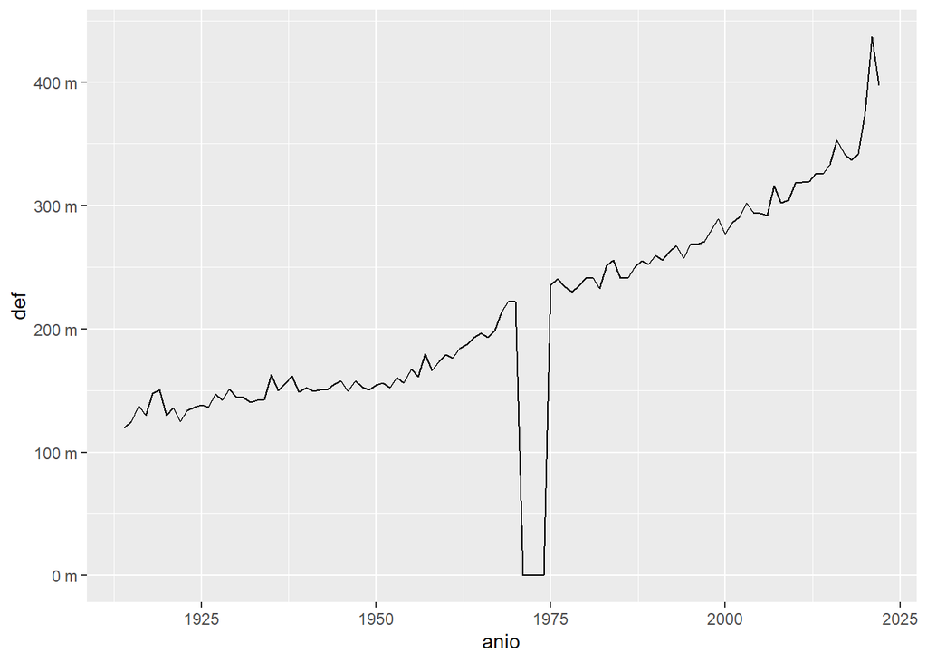

```r
grafico1 <- data2 |>
  filter(jurisdiccion=="republica_argentina") |>
  ggplot()+
  geom_line(aes(anio, def))+
  scale_y_continuous(labels = unit_format(unit = "m", scale = 1e-3))
grafico1
```

```r
#help("coalesce")
#usamos una funcion de dplyr para convertir 0 en NA
#los valores de ciertas jurisdicciones que hayan tenido 0 defunciones...
#se convertiran en Nulos
data2$def <- na_if(data2$def, 0)
summary(data2)
```

```
##       anio      jurisdiccion            def
##  Min.   :1914   Length:2725        Min.   :     3
##  1st Qu.:1941   Class :character   1st Qu.:  1634
##  Median :1968   Mode  :character   Median :  3955
##  [ reached getOption("max.print") -- omitted 4 rows ]
```

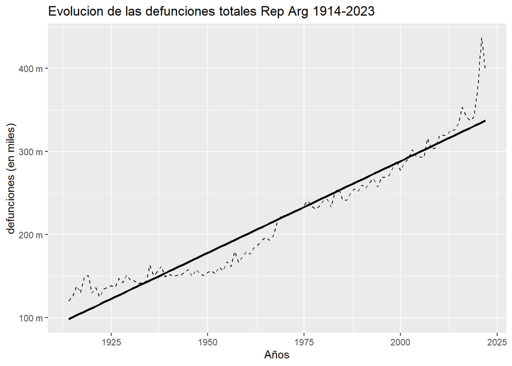

```r
grafico1 <- data2 |>
  filter(jurisdiccion=="republica_argentina") |>
  ggplot( aes(anio, def))+
  geom_line(linetype = 2)+
  geom_smooth(method = "glm", colour = "black", se = FALSE)+
  scale_y_continuous(labels = unit_format(unit = "m", scale = 1e-3))+
  ggtitle("Evolucion de las defunciones totales Rep Arg 1914-2023")+
  ylab("defunciones (en miles)")+
  xlab("Años")

grafico1
```

Veamos otro grafico donde se vean por provincias

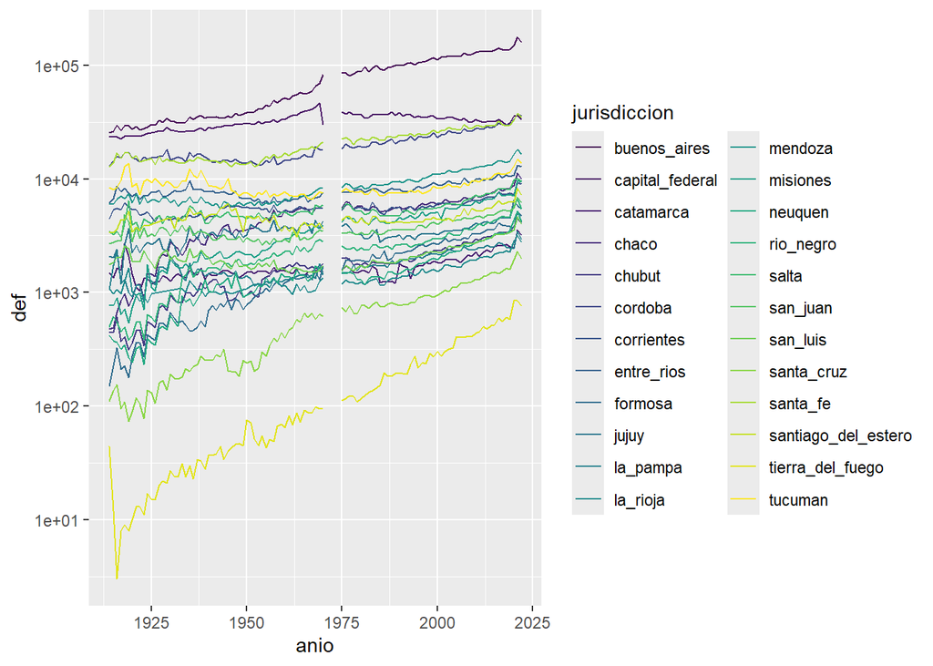

```r
grafico2 <- data2 |>
filter(jurisdiccion!="republica_argentina") |>
ggplot(aes(x=anio, y=def, group = jurisdiccion, color=jurisdiccion))+
geom_line()+
scale_y_log10()+
scale_color_viridis(discrete=TRUE)
grafico2
```

```r
#library(ggrepel)
# grafico2 <- data2 |>
#   mutate(label_graf = if_else(anio == max(anio), as.character(jurisdiccion), NA_character_)) |>
#   filter(jurisdiccion!="republica_argentina") |>
#   ggplot( aes(x= anio, y= def, group = jurisdiccion, colour=jurisdiccion))+
#   geom_line()+
#   scale_y_log10()+
#   geom_label_repel(aes(label = label_graf),
#                   nudge_x = 3,
#                   direction = "y",
#                   hjust="right",
#                   max.overlaps = Inf,
#                   na.rm = TRUE)+
#   theme(legend.position = "none")+
#    scale_color_viridis(discrete=TRUE)
# grafico2
```

Veamos un caso particular

```r
provincias <- data2 |>
  select(jurisdiccion) |>
  filter(jurisdiccion !="republica_argentina") |>
  unique()
provincias
```

```
## # A tibble: 24 × 1
##    jurisdiccion
##    <chr>
##  1 capital_federal
##  2 buenos_aires
##  3 catamarca
##  4 cordoba
##  5 corrientes
##  6 chaco
##  7 chubut
##  8 entre_rios
##  9 formosa
## 10 jujuy
## # ℹ 14 more rows
```

```r
#escrribimos un

#write_excel_csv(provincias, "~/GitHub/mortalidad_historica/provincias.csv")
```

Ahora si queremos ver un mapa, o cuando debamos unir los datos de poblacion por provincia… necesitamos un codigo unico, o el mismo exacto nombre. para eviatr problemas o mayores esfuerzos, utilizamos la libreria GeoAr

```r
normalizados <- get_provincias(nombre = provincias$jurisdiccion[3], max = 1)
normalizados
```

```
## # A tibble: 1 × 4
##   centroide_lat centroide_lon id    nombre
##           <dbl>         <dbl> <chr> <chr>
## 1         -27.3         -66.9 10    Catamarca
```

Encuentra Catamarca, pero buenos_aires No se esperaban nombres separados por guion bajo? Entonces quitemos el guio bajo.

```r
provincias <- provincias |>
  mutate(
    provincia = gsub("_", " ", provincias$jurisdiccion)
  )
provincias
```

```
## # A tibble: 24 × 2
##    jurisdiccion    provincia
##    <chr>           <chr>
##  1 capital_federal capital federal
##  2 buenos_aires    buenos aires
##  3 catamarca       catamarca
##  4 cordoba         cordoba
##  5 corrientes      corrientes
##  6 chaco           chaco
##  7 chubut          chubut
##  8 entre_rios      entre rios
##  9 formosa         formosa
## 10 jujuy           jujuy
## # ℹ 14 more rows
```

Y ahora?

```r
normalizados <- get_provincias(nombre = provincias$provincia[1], max = 1)
normalizados
```

```
## # A tibble: 1 × 4
##   centroide_lat centroide_lon id    nombre
##           <dbl>         <dbl> <chr> <chr>
## 1         -34.6         -58.4 02    Ciudad Autónoma de Buenos Aires
```

Ahora en el mismo tutorial vemos como convertir esta lista en una nueva. Mediante una funcion, y luego aplicada a la tabla.

```r
normalizar <- function(base){

  tmp <- get_provincias(nombre = base, max = 1)

  tmp$nombre
}
```

Aplicamos esta funcion al listado

```r
(lista_normalizada <- provincias |>
  mutate(
    normalizada = map_chr(.x = provincia,
                          .f = ~normalizar(base = .x)
                          )
         ))
```

```
## # A tibble: 24 × 3
##    jurisdiccion    provincia       normalizada
##    <chr>           <chr>           <chr>
##  1 capital_federal capital federal Ciudad Autónoma de Buenos Aires
##  2 buenos_aires    buenos aires    Buenos Aires
##  3 catamarca       catamarca       Catamarca
##  4 cordoba         cordoba         Córdoba
##  5 corrientes      corrientes      Corrientes
##  6 chaco           chaco           Chaco
##  7 chubut          chubut          Chubut
##  8 entre_rios      entre rios      Entre Ríos
##  9 formosa         formosa         Formosa
## 10 jujuy           jujuy           Jujuy
## # ℹ 14 more rows
```

```r
lista_normalizada
```

```
## # A tibble: 24 × 3
##    jurisdiccion    provincia       normalizada
##    <chr>           <chr>           <chr>
##  1 capital_federal capital federal Ciudad Autónoma de Buenos Aires
##  2 buenos_aires    buenos aires    Buenos Aires
##  3 catamarca       catamarca       Catamarca
##  4 cordoba         cordoba         Córdoba
##  5 corrientes      corrientes      Corrientes
##  6 chaco           chaco           Chaco
##  7 chubut          chubut          Chubut
##  8 entre_rios      entre rios      Entre Ríos
##  9 formosa         formosa         Formosa
## 10 jujuy           jujuy           Jujuy
## # ℹ 14 more rows
```

Ahora que sabemos que obtenemos los datos normalizados, se puede obtener ademas, la coord del centroide, y otras.. Nose como…

pero si veo que le paquete trae un dataset llamado `geo_metadata` y la funcion `show_arg_codes()`

necesito el codprov_censo o 4ta columna

uniendo geo_metadata$name_iso

O alternativamente, extraer la geo de cada provincia y desde ahi obtener a la inversa los codigos…

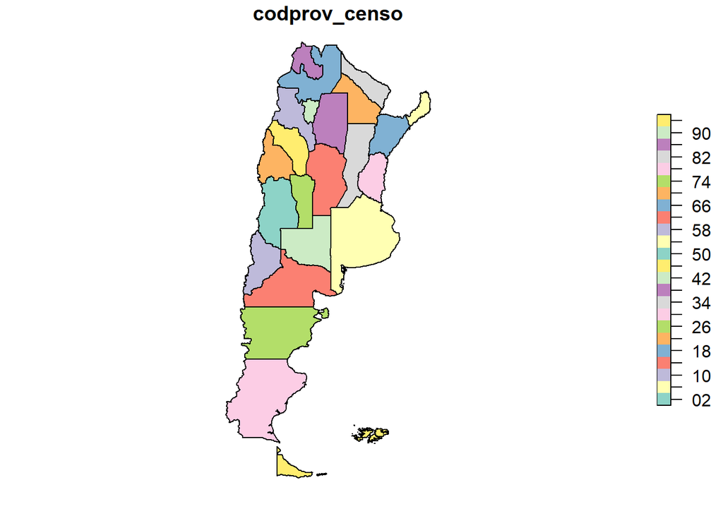

```r
geo_provincias <- get_geo(geo = "ARGENTINA", level = "provincia")
plot(geo_provincias)
```

y ahora obtengo los codigos desde este conjunto de datos

```r
provinicas_datos <- geo_provincias |>
  add_geo_codes()
provinicas_datos
```

```
## Simple feature collection with 24 features and 4 fields
## Geometry type: MULTIPOLYGON
## Dimension:     XY
## Bounding box:  xmin: -73.57219 ymin: -55.05803 xmax: -53.64276 ymax: -21.74531
## Geodetic CRS:  WGS 84
## # A tibble: 24 × 5
##    codprov_censo codprov codprov_iso name_iso                           geometry
##    <chr>         <chr>   <chr>       <chr>                    <MULTIPOLYGON [°]>
##  1 02            01      AR-C        Ciudad Autónoma … (((-58.42899 -34.55194, …
##  2 10            03      AR-K        Catamarca         (((-65.12069 -28.19071, …
##  3 14            04      AR-X        Córdoba           (((-63.64637 -35.00773, …
##  4 18            05      AR-W        Corrientes        (((-57.84345 -30.72212, …
##  5 22            06      AR-H        Chaco             (((-58.8921 -28.04254, -…
##  6 30            08      AR-E        Entre Ríos        (((-58.46224 -34.00243, …
##  7 34            09      AR-P        Formosa           (((-58.39822 -26.85617, …
##  8 38            10      AR-Y        Jujuy             (((-67.19479 -23.60412, …
##  9 42            11      AR-L        La Pampa          (((-63.45696 -39.32857, …
## 10 46            12      AR-F        La Rioja          (((-65.80143 -31.90577, …
## # ℹ 14 more rows
```

Ahora creamos un nuevo dataset del original, uniendo los nombres con los normalizados. y luego con esta tabla que obtuvimos al final.

```r
data3 <- left_join(data2, lista_normalizada, by= "jurisdiccion") |>
  filter(jurisdiccion!="republica_argentina") |>
  select(anio, def, normalizada)

data3
```

```
## # A tibble: 2,616 × 3
##     anio   def normalizada
##    <int> <int> <chr>
##  1  1914 23486 Ciudad Autónoma de Buenos Aires
##  2  1914 25599 Buenos Aires
##  3  1914  1483 Catamarca
##  4  1914 12939 Córdoba
##  5  1914  4483 Corrientes
##  6  1914   475 Chaco
##  7  1914   453 Chubut
##  8  1914  6124 Entre Ríos
##  9  1914   149 Formosa
## 10  1914  2084 Jujuy
## # ℹ 2,606 more rows
```

## Pendientes

- Datos de poblacion
- Censos
- Poblacion por años